# Visualizing sports data: basketball

In this notebook we're going to look at ways of visualizing performance in basketball. We are going to use the data that we were introduced to last week.

Our analysis here is going to focus on the where the ball was thrown from, which is recorded using (x, y) co-ordinates, in the same way that we had the coordinates for the baseball data. This data is easy to graph and illuminating.

We choose three different ways to look at the data

1. shot outcome: scored, missed or blocked
2. shot types by player
3. narrowing the focus to a particular region of the court

```python
# As usual, we begin by importing the packages we will need

import pandas as pd
import numpy as np
import matplotlib.pyplot as plt
```

```python
# The data consists of the shot log for the NBA season 2016/17

shot = pd.read_csv("../../Data/Week 3/NBA Shotlog_16_17.csv")
pd.set_option('display.max_columns', 100)
print(shot.columns.tolist())
shot.describe()
```

```
['self_previous_shot', 'player_position', 'home_game', 'location_x', 'opponent_previous_shot', 'home_team', 'shot_type', 'points', 'away_team', 'location_y', 'time', 'date', 'shoot_player', 'time_from_last_shot', 'quarter', 'current_shot_outcome']
```

|  | location_x | points | location_y | time_from_last_shot | quarter |
| --- | --- | --- | --- | --- | --- |
| count | 209675.000000 | 210072.000000 | 209675.00000 | 200072.000000 | 210072.000000 |
| mean | 468.524507 | 2.316130 | 249.44723 | 33.279489 | 2.480383 |
| std | 345.063654 | 0.464965 | 111.02320 | 19.797357 | 1.136841 |
| min | 0.000000 | 2.000000 | 0.00000 | 0.000000 | 1.000000 |
| 25% | 94.000000 | 2.000000 | 197.00000 | 22.000000 | 1.000000 |
| 50% | 342.000000 | 2.000000 | 250.00000 | 31.000000 | 2.000000 |
| 75% | 843.000000 | 3.000000 | 303.00000 | 41.000000 | 3.000000 |
| max | 933.000000 | 3.000000 | 500.00000 | 255.000000 | 8.000000 |

We can generate a simple plot as follows:

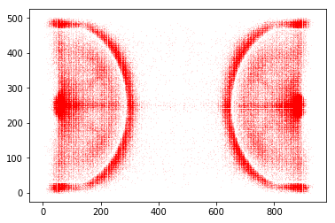

```python
# A simple plot of coordinates

x = shot['location_x']
y = shot['location_y']
plt.scatter(x,y, s=.005,c='r', marker= '.')
```

One point to note about the data is that it does not include free throws - otherwise there would be a deep red concentration at the center of the free throw line.

The plot above gives us a very clear picture of the location of shots, notably from under the basket and from the three point line. However, the plot does not take account of the proportions of the court. Moreover, it would be useful to add a grid to identify more clearly the different locations.

The dimensions of the court defined by the NBA are 94 feet by 50 feet. We can specify that ratio using figsize = (a,b). Note that we can also scale this to control the size of the plot in our window (we divide both the x and y figsize by 6).

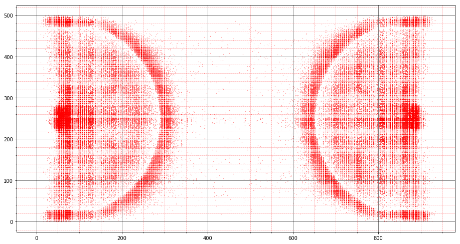

```python
# A simple plot of coordinates, scaled for court dimensions and with grid added.

plt.figure(figsize=(94/6,50/6))
plt.scatter(x,y, s=.1,c='r', marker= '.')
plt.minorticks_on()
plt.grid(which='major', linestyle='-', linewidth='.5', color='black')
plt.grid(which='minor', linestyle=':', linewidth='0.5', color='red')
```

Rather than look at both ends of the court, we can just look at one half of the court by fixing the range of the x axis using plt.xlim, which we set to cover the right hand half court. Note that to maintain the same dimensions we also need to halve the x axis on figsize (to 94/12 rather than 94/6).

```
(466.5, 933)
```

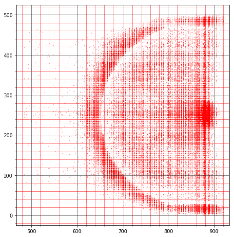

```python
# The right hand half court

plt.figure(figsize=(94/12,50/6))
plt.scatter(x,y, s=.1,c='r', marker= '.')
plt.minorticks_on()
plt.grid(which='major', linewidth='.5', color='black')
plt.grid(which='minor', linewidth='.5', color='red')
plt.xlim(933/2, 933)
```

The last plot just shows us one half of the court. To include both halves but show only the half court, we can convert the coordinates from the left hand half court so that they have the same relative location on the right hand half court (of course, there should be no real difference in performance based on which end of the court the player is attacking, and the two halves are mirror images of each other).

We can convert the plot to show shots from both ends on a half court if we adjust the coordinates. The x-axis runs from 0 to 933, so if we want to just show the right hand half court with all shots, we can recode the location_x variables, where x is less the 933/2 (the left had half court) as equal to "933 - location_x". This produces a mirror image of the x coordinate in the right hand half of the court. However, since the direction toward the basket is the reverse of the other half court, we need to take the mirror image of the y coordinate for shots in the left had half court - that is "500 - location_y".

The following code (which works like an "if" statement in Excel) creates these mirror images:

```python
shot['halfcourt_x'] =np.where(shot['location_x'] < 933/2, 933 - shot['location_x'],shot['location_x'])
shot['halfcourt_y'] =np.where(shot['location_x'] < 933/2, 500 - shot['location_y'],shot['location_y'])
shot.describe()
```

|  | location_x | points | location_y | time_from_last_shot | quarter | halfcourt_x | halfcourt_y |
| --- | --- | --- | --- | --- | --- | --- | --- |
| count | 209675.000000 | 210072.000000 | 209675.00000 | 200072.000000 | 210072.000000 | 209675.000000 | 209675.000000 |
| mean | 468.524507 | 2.316130 | 249.44723 | 33.279489 | 2.480383 | 799.731480 | 250.303947 |
| std | 345.063654 | 0.464965 | 111.02320 | 19.797357 | 1.136841 | 89.606222 | 111.024160 |
| min | 0.000000 | 2.000000 | 0.00000 | 0.000000 | 1.000000 | 468.000000 | 0.000000 |
| 25% | 94.000000 | 2.000000 | 197.00000 | 22.000000 | 1.000000 | 720.000000 | 197.000000 |
| 50% | 342.000000 | 2.000000 | 250.00000 | 31.000000 | 2.000000 | 841.000000 | 250.000000 |
| 75% | 843.000000 | 3.000000 | 303.00000 | 41.000000 | 3.000000 | 878.000000 | 303.000000 |
| max | 933.000000 | 3.000000 | 500.00000 | 255.000000 | 8.000000 | 933.000000 | 500.000000 |

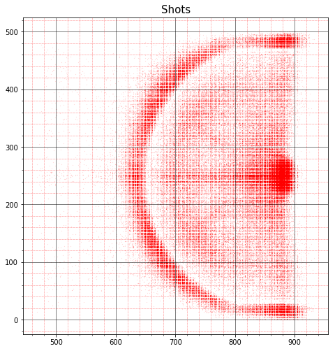

```python
# all shots shown on a half court

hx = shot['halfcourt_x']
hy = shot['halfcourt_y']
plt.figure(figsize=(94/12,50/6))
plt.scatter(hx,hy, s=.01,c='r', marker= '.')
plt.minorticks_on()
plt.grid(which='major', linestyle='-', linewidth='.5', color='black')
plt.grid(which='minor', linestyle=':', linewidth='0.5', color='red')
plt.title("Shots", fontsize = 15)
```

## Easy self test

Experiment with different sized markers. What size do you think gives you the best visual representation of the data? Why?

## More difficult self test

Show all the shots on a halfcourt, but show the data with the baseline on the left, not on the right.

We now breakdown shots into three categories: scored, missed and blocked. To do this we simply create subsets of the shot df based on shot outcome.

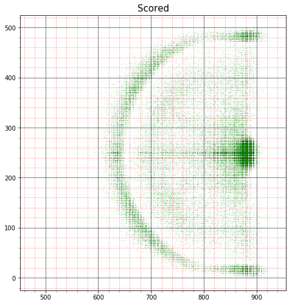

```python
# Scoring shots

Scored = shot[shot.current_shot_outcome == 'SCORED']
hxs = Scored['halfcourt_x']
hys = Scored['halfcourt_y']
plt.figure(figsize=(94/12,50/6))
plt.scatter(hxs,hys, s=.01,c='g', marker= '.')
plt.minorticks_on()
plt.grid(which='major', linestyle='-', linewidth='.5', color='black')
plt.grid(which='minor', linestyle=':', linewidth='0.5', color='red')
plt.title("Scored", fontsize = 15)
```

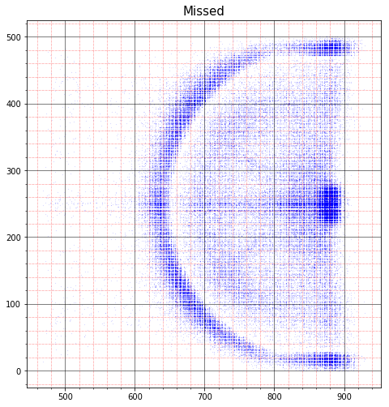

```python
# Missed Shots

Missed = shot[shot.current_shot_outcome == 'MISSED']

hxm = Missed['halfcourt_x']
hym = Missed['halfcourt_y']

plt.figure(figsize=(94/12,50/6))
plt.scatter(hxm,hym, s=.01,c='b', marker= '.')
plt.minorticks_on()
plt.grid(which='major', linestyle='-', linewidth='.5', color='black')
plt.grid(which='minor', linestyle=':', linewidth='0.5', color='red')
plt.title("Missed", fontsize = 15)
```

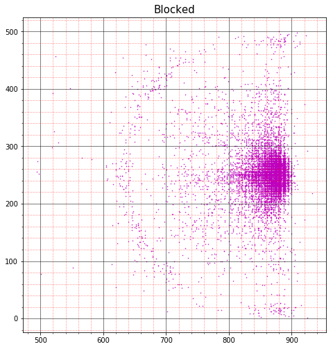

```python
# Blocked shots

Blocked = shot[shot.current_shot_outcome == 'BLOCKED']

hxb = Blocked['halfcourt_x']
hyb = Blocked['halfcourt_y']

plt.figure(figsize=(94/12,50/6))
plt.scatter(hxb,hyb, s=1,c='m', marker= '.')
plt.minorticks_on()
plt.grid(which='major', linestyle='-', linewidth='.5', color='black')
plt.grid(which='minor', linestyle=':', linewidth='0.5', color='red')
plt.title("Blocked", fontsize = 15)
```

While informative, the location of shots by shot type is not that surprising. There has been a lot of interest in recent years in the rise of the 3-point shot with evidence suggesting that in the past there were more more shots from distance inside the three-point line, and that these have tended to die out since the payoff is much lower than a shot from just outside the three-point. We don't have past data here to make the comparison.

Probably the greatest interest lies in comparing individual players. We can do this easily by taking subsets as we did above. First it's useful to generate a list of player names.

```python
# Comparing players

# We use a pivot table here to list players by shots

playersn = shot.groupby('shoot_player')['current_shot_outcome'].describe().reset_index()
playersn.sort_values(by = 'count', ascending = False)
```

|  | shoot_player | count | unique | top | freq |
| --- | --- | --- | --- | --- | --- |
| 402 | Russell Westbrook | 1940 | 3 | MISSED | 1026 |
| 25 | Andrew Wiggins | 1568 | 3 | MISSED | 760 |
| 106 | DeMar DeRozan | 1545 | 3 | MISSED | 731 |
| 193 | James Harden | 1532 | 3 | MISSED | 772 |
| 28 | Anthony Davis | 1525 | 3 | SCORED | 770 |
| 88 | Damian Lillard | 1489 | 3 | MISSED | 728 |
| 257 | Karl-Anthony Towns | 1479 | 3 | SCORED | 802 |
| 175 | Isaiah Thomas | 1473 | 3 | SCORED | 682 |
| 262 | Kemba Walker | 1451 | 3 | MISSED | 695 |
| 424 | Stephen Curry | 1444 | 3 | MISSED | 713 |
| 62 | CJ McCollum | 1441 | 3 | SCORED | 692 |
| 230 | John Wall | 1434 | 3 | MISSED | 701 |
| 107 | DeMarcus Cousins | 1433 | 3 | MISSED | 681 |
| 119 | Devin Booker | 1430 | 3 | MISSED | 732 |
| 282 | Kyrie Irving | 1420 | 3 | MISSED | 673 |
| 68 | Carmelo Anthony | 1390 | 3 | MISSED | 750 |
| 271 | Klay Thompson | 1376 | 3 | MISSED | 689 |
| 370 | Paul George | 1348 | 3 | MISSED | 673 |
| 291 | LeBron James | 1344 | 3 | SCORED | 736 |
| 48 | Bradley Beal | 1321 | 3 | SCORED | 637 |
| 258 | Kawhi Leonard | 1312 | 3 | MISSED | 643 |
| 166 | Harrison Barnes | 1280 | 3 | MISSED | 631 |
| 158 | Giannis Antetokounmpo | 1257 | 3 | SCORED | 656 |
| 216 | Jimmy Butler | 1252 | 3 | MISSED | 624 |
| 112 | Dennis Schroder | 1215 | 3 | MISSED | 555 |
| 58 | Brook Lopez | 1173 | 3 | MISSED | 568 |
| 305 | Marc Gasol | 1160 | 3 | MISSED | 605 |
| 161 | Gordon Hayward | 1154 | 3 | MISSED | 567 |
| 160 | Goran Dragic | 1125 | 3 | SCORED | 534 |
| 237 | Jordan Clarkson | 1069 | 3 | MISSED | 534 |
| ... | ... | ... | ... | ... | ... |
| 240 | Jordan Hill | 13 | 3 | MISSED | 7 |
| 303 | Manny Harris | 13 | 3 | MISSED | 7 |
| 123 | Diamond Stone | 13 | 3 | MISSED | 7 |
| 252 | Justin Harper | 12 | 3 | MISSED | 6 |
| 139 | Elliott Williams | 12 | 3 | SCORED | 6 |
| 239 | Jordan Farmar | 12 | 3 | MISSED | 7 |
| 244 | Josh Huestis | 11 | 2 | SCORED | 6 |
| 328 | Michael Gbinije | 10 | 2 | MISSED | 9 |
| 37 | Axel Toupane | 9 | 2 | SCORED | 5 |
| 164 | Greivis Vasquez | 8 | 3 | MISSED | 5 |
| 73 | Chinanu Onuaku | 7 | 2 | SCORED | 5 |
| 309 | Marcus Georges-Hunt | 7 | 2 | MISSED | 5 |
| 57 | Brice Johnson | 7 | 3 | MISSED | 4 |
| 364 | Patricio Garino | 7 | 1 | MISSED | 7 |
| 138 | Elijah Millsap | 7 | 2 | MISSED | 6 |
| 151 | Gary Neal | 7 | 1 | MISSED | 7 |
| 174 | Isaiah Taylor | 7 | 3 | MISSED | 5 |
| 426 | Steve Novak | 7 | 2 | MISSED | 5 |
| 472 | Walter Tavares | 5 | 2 | SCORED | 4 |
| 228 | John Jenkins | 5 | 2 | MISSED | 3 |
| 289 | Larry Sanders | 4 | 2 | MISSED | 3 |
| 229 | John Lucas III | 4 | 2 | MISSED | 3 |
| 335 | Mike Tobey | 4 | 3 | MISSED | 2 |
| 32 | Arinze Onuaku | 4 | 2 | SCORED | 2 |
| 3 | Aaron Harrison | 4 | 1 | MISSED | 4 |
| 111 | Demetrius Jackson | 4 | 2 | SCORED | 3 |
| 203 | Jarrett Jack | 3 | 2 | SCORED | 2 |
| 38 | Ben Bentil | 3 | 1 | MISSED | 3 |
| 202 | Jarnell Stokes | 1 | 1 | SCORED | 1 |
| 377 | RJ Hunter | 1 | 1 | MISSED | 1 |

485 rows × 5 columns

We now compare LeBron James with Steph Curry.

```python
# LeBron subset

LeBron = shot[shot['shoot_player']=='LeBron James']
LeBron
```

|  | self_previous_shot | player_position | home_game | location_x | opponent_previous_shot | home_team | shot_type | points | away_team | location_y | time | date | shoot_player | time_from_last_shot | quarter | current_shot_outcome | halfcourt_x | halfcourt_y |
| --- | --- | --- | --- | --- | --- | --- | --- | --- | --- | --- | --- | --- | --- | --- | --- | --- | --- | --- |
| 35023 | MISSED | SF | Yes | 131.0 | SCORED | CLE | Jump Shot | 2 | NYK | 171.0 | 1:01 | 10/25/2016 | LeBron James | 27.0 | 1 | SCORED | 802.0 | 329.0 |
| 35028 | MISSED | SF | Yes | 236.0 | MISSED | CLE | Jump Shot | 3 | NYK | 84.0 | 2:33 | 10/25/2016 | LeBron James | 6.0 | 1 | MISSED | 697.0 | 416.0 |
| 35030 | BLOCKED | SF | Yes | 264.0 | SCORED | CLE | Jump Shot | 3 | NYK | 383.0 | 3:44 | 10/25/2016 | LeBron James | 42.0 | 1 | MISSED | 669.0 | 117.0 |
| 35037 | SCORED | SF | Yes | 50.0 | MISSED | CLE | Running Layup | 2 | NYK | 259.0 | 6:04 | 10/25/2016 | LeBron James | 17.0 | 1 | SCORED | 883.0 | 241.0 |
| 35044 | MISSED | SF | Yes | 52.0 | SCORED | CLE | Putback Dunk | 2 | NYK | 250.0 | 8:23 | 10/25/2016 | LeBron James | 4.0 | 1 | SCORED | 881.0 | 250.0 |
| 35054 | MISSED | SF | Yes | 52.0 | MISSED | CLE | Dunk | 2 | NYK | 250.0 | 1:05 | 10/25/2016 | LeBron James | 25.0 | 2 | SCORED | 881.0 | 250.0 |
| 35055 | SCORED | SF | Yes | 67.0 | MISSED | CLE | Running Layup | 2 | NYK | 275.0 | 1:18 | 10/25/2016 | LeBron James | 13.0 | 2 | MISSED | 866.0 | 225.0 |
| 35061 | MISSED | SF | Yes | 52.0 | SCORED | CLE | Running Dunk | 2 | NYK | 250.0 | 3:24 | 10/25/2016 | LeBron James | 12.0 | 2 | SCORED | 881.0 | 250.0 |
| 35062 | SCORED | SF | Yes | 52.0 | BLOCKED | CLE | Alley Oop Dunk | 2 | NYK | 250.0 | 4:27 | 10/25/2016 | LeBron James | 63.0 | 2 | SCORED | 881.0 | 250.0 |
| 35073 | MISSED | SF | Yes | 50.0 | SCORED | CLE | Jump Shot | 3 | NYK | 485.0 | 10:45 | 10/25/2016 | LeBron James | 89.0 | 2 | MISSED | 883.0 | 15.0 |
| 35074 | MISSED | SF | Yes | 151.0 | MISSED | CLE | Floating Jump Shot | 2 | NYK | 274.0 | 11:08 | 10/25/2016 | LeBron James | 23.0 | 2 | MISSED | 782.0 | 226.0 |
| 35081 | SCORED | SF | Yes | 888.0 | SCORED | CLE | Driving Dunk | 2 | NYK | 250.0 | 2:55 | 10/25/2016 | LeBron James | 30.0 | 3 | SCORED | 888.0 | 250.0 |
| 35082 | SCORED | SF | Yes | 888.0 | SCORED | CLE | Running Dunk | 2 | NYK | 250.0 | 3:14 | 10/25/2016 | LeBron James | 19.0 | 3 | SCORED | 888.0 | 250.0 |
| 35101 | SCORED | SF | Yes | 814.0 | MISSED | CLE | Turnaround Jump Shot | 2 | NYK | 220.0 | 2:49 | 10/25/2016 | LeBron James | 22.0 | 4 | SCORED | 814.0 | 220.0 |
| 35121 | MISSED | SF | No | 833.0 | MISSED | TOR | Driving Floating Jump Shot | 2 | CLE | 257.0 | 2:29 | 10/28/2016 | LeBron James | 24.0 | 1 | MISSED | 833.0 | 257.0 |
| 35122 | MISSED | SF | No | 878.0 | MISSED | TOR | Driving Layup | 2 | CLE | 250.0 | 2:47 | 10/28/2016 | LeBron James | 18.0 | 1 | MISSED | 878.0 | 250.0 |
| 35127 | SCORED | SF | No | 882.0 | MISSED | TOR | Running Layup | 2 | CLE | 218.0 | 4:48 | 10/28/2016 | LeBron James | 45.0 | 1 | SCORED | 882.0 | 218.0 |
| 35133 | SCORED | SF | No | 878.0 | SCORED | TOR | Driving Floating Jump Shot | 2 | CLE | 342.0 | 8:13 | 10/28/2016 | LeBron James | 28.0 | 1 | MISSED | 878.0 | 342.0 |
| 35134 | MISSED | SF | No | 895.0 | SCORED | TOR | Jump Shot | 3 | CLE | 477.0 | 8:18 | 10/28/2016 | LeBron James | 5.0 | 1 | SCORED | 895.0 | 477.0 |
| 35143 | MISSED | SF | No | 878.0 | SCORED | TOR | Layup | 2 | CLE | 262.0 | 1:32 | 10/28/2016 | LeBron James | 34.0 | 2 | SCORED | 878.0 | 262.0 |
| 35144 | SCORED | SF | No | 886.0 | MISSED | TOR | Driving Floating Bank Jump Shot | 2 | CLE | 220.0 | 3:46 | 10/28/2016 | LeBron James | 134.0 | 2 | SCORED | 886.0 | 220.0 |
| 35147 | SCORED | SF | No | 886.0 | MISSED | TOR | Driving Layup | 2 | CLE | 262.0 | 5:53 | 10/28/2016 | LeBron James | 45.0 | 2 | MISSED | 886.0 | 262.0 |
| 35149 | MISSED | SF | No | 878.0 | MISSED | TOR | Jump Shot | 3 | CLE | 7.0 | 6:34 | 10/28/2016 | LeBron James | 19.0 | 2 | MISSED | 878.0 | 7.0 |
| 35167 | SCORED | SF | No | 303.0 | SCORED | TOR | Pullup Jump Shot | 3 | CLE | 341.0 | 4:50 | 10/28/2016 | LeBron James | 58.0 | 3 | MISSED | 630.0 | 159.0 |
| 35169 | SCORED | SF | No | 310.0 | MISSED | TOR | Pullup Jump Shot | 3 | CLE | 275.0 | 6:29 | 10/28/2016 | LeBron James | 52.0 | 3 | MISSED | 623.0 | 225.0 |
| 35173 | SCORED | SF | No | 166.0 | SCORED | TOR | Pullup Jump Shot | 2 | CLE | 197.0 | 9:22 | 10/28/2016 | LeBron James | 41.0 | 3 | MISSED | 767.0 | 303.0 |
| 35175 | MISSED | SF | No | 274.0 | MISSED | TOR | Pullup Jump Shot | 3 | CLE | 117.0 | 11:55 | 10/28/2016 | LeBron James | 86.0 | 3 | SCORED | 659.0 | 383.0 |
| 35183 | SCORED | SF | No | 40.0 | SCORED | TOR | Layup | 2 | CLE | 277.0 | 5:03 | 10/28/2016 | LeBron James | 24.0 | 4 | SCORED | 893.0 | 223.0 |
| 35185 | MISSED | SF | No | 52.0 | MISSED | TOR | Cutting Dunk Shot | 2 | CLE | 250.0 | 6:36 | 10/28/2016 | LeBron James | 21.0 | 4 | SCORED | 881.0 | 250.0 |
| 35194 | SCORED | SF | No | 177.0 | MISSED | TOR | Step Back Jump Shot | 3 | CLE | 465.0 | 11:44 | 10/28/2016 | LeBron James | 28.0 | 4 | MISSED | 756.0 | 35.0 |
| ... | ... | ... | ... | ... | ... | ... | ... | ... | ... | ... | ... | ... | ... | ... | ... | ... | ... | ... |
| 41683 | MISSED | SF | Yes | 900.0 | MISSED | CLE | Running Layup | 2 | ATL | 241.0 | 0:30 | 4/7/2017 | LeBron James | NaN | 3 | SCORED | 900.0 | 241.0 |
| 41684 | SCORED | SF | Yes | 894.0 | MISSED | CLE | Driving Layup | 2 | ATL | 256.0 | 0:55 | 4/7/2017 | LeBron James | 25.0 | 3 | SCORED | 894.0 | 256.0 |
| 41690 | SCORED | SF | Yes | 888.0 | SCORED | CLE | Cutting Dunk Shot | 2 | ATL | 250.0 | 5:06 | 4/7/2017 | LeBron James | 35.0 | 3 | SCORED | 888.0 | 250.0 |
| 41693 | MISSED | SF | Yes | 878.0 | SCORED | CLE | Layup | 2 | ATL | 259.0 | 6:44 | 4/7/2017 | LeBron James | 29.0 | 3 | SCORED | 878.0 | 259.0 |
| 41697 | MISSED | SF | Yes | 890.0 | SCORED | CLE | Driving Layup | 2 | ATL | 250.0 | 9:35 | 4/7/2017 | LeBron James | 36.0 | 3 | SCORED | 890.0 | 250.0 |
| 41705 | SCORED | SF | Yes | 890.0 | MISSED | CLE | Driving Layup | 2 | ATL | 248.0 | 2:11 | 4/7/2017 | LeBron James | 33.0 | 4 | MISSED | 890.0 | 248.0 |
| 41706 | MISSED | SF | Yes | 890.0 | MISSED | CLE | Running Layup | 2 | ATL | 251.0 | 2:27 | 4/7/2017 | LeBron James | 16.0 | 4 | SCORED | 890.0 | 251.0 |
| 41717 | MISSED | SF | Yes | 828.0 | SCORED | CLE | Turnaround Jump Shot | 2 | ATL | 270.0 | 8:42 | 4/7/2017 | LeBron James | 41.0 | 4 | MISSED | 828.0 | 270.0 |
| 41719 | SCORED | SF | Yes | 886.0 | SCORED | CLE | Driving Layup | 2 | ATL | 262.0 | 9:29 | 4/7/2017 | LeBron James | 33.0 | 4 | SCORED | 886.0 | 262.0 |
| 41723 | SCORED | SF | No | 853.0 | MISSED | ATL | Driving Layup | 2 | CLE | 254.0 | 1:09 | 4/9/2017 | LeBron James | 31.0 | 1 | BLOCKED | 853.0 | 254.0 |
| 41737 | SCORED | SF | No | 706.0 | BLOCKED | ATL | Step Back Jump Shot | 3 | CLE | 423.0 | 7:42 | 4/9/2017 | LeBron James | 61.0 | 1 | MISSED | 706.0 | 423.0 |
| 41738 | MISSED | SF | No | 888.0 | MISSED | ATL | Running Dunk | 2 | CLE | 250.0 | 8:20 | 4/9/2017 | LeBron James | 38.0 | 1 | SCORED | 888.0 | 250.0 |
| 41740 | MISSED | SF | No | 889.0 | MISSED | ATL | Tip Layup Shot | 2 | CLE | 238.0 | 8:48 | 4/9/2017 | LeBron James | 3.0 | 1 | SCORED | 889.0 | 238.0 |
| 41748 | MISSED | SF | No | 871.0 | SCORED | ATL | Jump Shot | 2 | CLE | 81.0 | 1:55 | 4/9/2017 | LeBron James | 46.0 | 2 | MISSED | 871.0 | 81.0 |
| 41749 | MISSED | SF | No | 888.0 | MISSED | ATL | Driving Dunk | 2 | CLE | 250.0 | 2:11 | 4/9/2017 | LeBron James | 16.0 | 2 | SCORED | 888.0 | 250.0 |
| 41764 | SCORED | SF | No | 878.0 | SCORED | ATL | Layup | 2 | CLE | 251.0 | 9:58 | 4/9/2017 | LeBron James | 26.0 | 2 | SCORED | 878.0 | 251.0 |
| 41765 | SCORED | SF | No | 878.0 | SCORED | ATL | Layup | 2 | CLE | 235.0 | 10:47 | 4/9/2017 | LeBron James | 49.0 | 2 | MISSED | 878.0 | 235.0 |
| 41766 | MISSED | SF | No | 886.0 | SCORED | ATL | Putback Layup | 2 | CLE | 249.0 | 10:50 | 4/9/2017 | LeBron James | 3.0 | 2 | SCORED | 886.0 | 249.0 |
| 41771 | MISSED | SF | No | 300.0 | SCORED | ATL | Pullup Jump Shot | 3 | CLE | 212.0 | 1:16 | 4/9/2017 | LeBron James | 29.0 | 3 | MISSED | 633.0 | 288.0 |
| 41772 | MISSED | SF | No | 254.0 | MISSED | ATL | Jump Shot | 3 | CLE | 97.0 | 1:39 | 4/9/2017 | LeBron James | 23.0 | 3 | SCORED | 679.0 | 403.0 |
| 41779 | SCORED | SF | No | 52.0 | SCORED | ATL | Driving Dunk | 2 | CLE | 250.0 | 5:35 | 4/9/2017 | LeBron James | 35.0 | 3 | SCORED | 881.0 | 250.0 |
| 41783 | MISSED | SF | No | 185.0 | MISSED | ATL | Pullup Jump Shot | 2 | CLE | 151.0 | 7:35 | 4/9/2017 | LeBron James | 31.0 | 3 | MISSED | 748.0 | 349.0 |
| 41785 | BLOCKED | SF | No | 52.0 | BLOCKED | ATL | Cutting Dunk Shot | 2 | CLE | 250.0 | 8:02 | 4/9/2017 | LeBron James | 2.0 | 3 | SCORED | 881.0 | 250.0 |
| 41790 | MISSED | SF | No | 58.0 | MISSED | ATL | Layup | 2 | CLE | 267.0 | 11:00 | 4/9/2017 | LeBron James | 18.0 | 3 | SCORED | 875.0 | 233.0 |
| 41791 | SCORED | SF | No | 269.0 | MISSED | ATL | Jump Shot | 2 | CLE | 197.0 | 11:27 | 4/9/2017 | LeBron James | 27.0 | 3 | MISSED | 664.0 | 303.0 |
| 41795 | MISSED | SF | No | 51.0 | SCORED | ATL | Driving Layup | 2 | CLE | 246.0 | 1:16 | 4/9/2017 | LeBron James | 47.0 | 4 | MISSED | 882.0 | 254.0 |
| 41798 | SCORED | SF | No | 58.0 | SCORED | ATL | Driving Layup | 2 | CLE | 249.0 | 3:36 | 4/9/2017 | LeBron James | 58.0 | 4 | SCORED | 875.0 | 251.0 |
| 41801 | SCORED | SF | No | 52.0 | MISSED | ATL | Driving Dunk | 2 | CLE | 250.0 | 5:54 | 4/9/2017 | LeBron James | 29.0 | 4 | SCORED | 881.0 | 250.0 |
| 41806 | SCORED | SF | No | 77.0 | SCORED | ATL | Fadeaway Jumper | 2 | CLE | 450.0 | 8:54 | 4/9/2017 | LeBron James | 31.0 | 4 | MISSED | 856.0 | 50.0 |
| 41813 | MISSED | SF | No | 141.0 | MISSED | ATL | Floating Jump Shot | 2 | CLE | 290.0 | 2:08 | 4/9/2017 | LeBron James | 76.0 | 5 | MISSED | 792.0 | 210.0 |

1344 rows × 18 columns

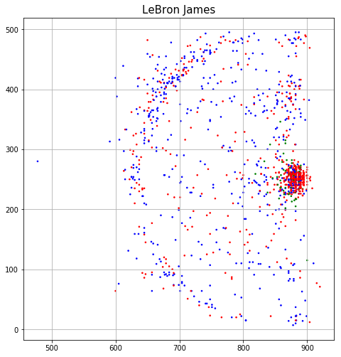

```python
# LeBron plot
# Note how the shots can be color coded using an np.where statement.

hxL = LeBron['halfcourt_x']
hyL = LeBron['halfcourt_y']
colors = np.where(LeBron['current_shot_outcome']=='SCORED','r',np.where(LeBron['current_shot_outcome']=='MISSED','b','g'))
plt.figure(figsize=(94/12,50/6))
plt.scatter(hxL,hyL, s=10, c= colors, marker= '.')
plt.grid(True)
plt.title("LeBron James", fontsize = 15)
```

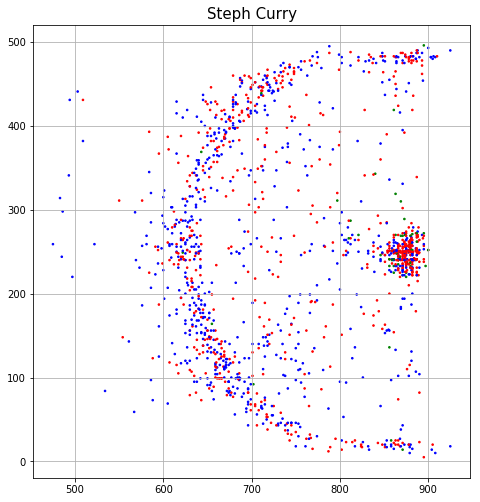

```python
# Steph Curry plot

Curry = shot[shot['shoot_player']=='Stephen Curry']
hxC = Curry['halfcourt_x']
hyC = Curry['halfcourt_y']
colors = np.where(Curry['current_shot_outcome']=='SCORED','r',np.where(Curry['current_shot_outcome']=='MISSED','b','g'))
plt.figure(figsize=(94/12,50/6))
plt.scatter(hxC,hyC, s=10, c= colors, marker= '.')
plt.grid(True)
plt.title("Steph Curry", fontsize = 15)
```

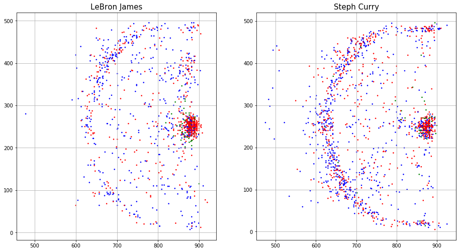

```python
# LeBron James and Steph Curry side by side

f = plt.figure(figsize=(94/6,50/6))
ax = f.add_subplot(121)
colors = np.where(LeBron['current_shot_outcome']=='SCORED','r',np.where(LeBron['current_shot_outcome']=='MISSED','b','g'))
ax = plt.scatter(hxL,hyL, s=10, c= colors, marker= '.')
plt.grid(True)
plt.title("LeBron James", fontsize = 15)
ax = f.add_subplot(122)
colors = np.where(Curry['current_shot_outcome']=='SCORED','r',np.where(Curry['current_shot_outcome']=='MISSED','b','g'))
ax = plt.scatter(hxC,hyC, s=10, c= colors, marker= '.')
plt.grid(True)
plt.title("Steph Curry", fontsize = 15)
```

These simple plots make clear some of the differences between the two players. It is clearly visible that Curry shoots more from the three-point line than LeBron, while LeBron is more active on the paint. Some more subtle differences are also visible. LeBron is more active on the left hand side of the court, while Curry is equally active on both sides. Curry also shoots more thre-pointers from the corners.

## Self Test

Identify two other players in the data and generate a similar comparison for those players.

As a final exercise we zoom in on the data to see what it looks like close up. We can identify a particular location based on our grid. First, we look at shots from the paint. We can define the paint here as x coordinates between 700 and 900, and y coordinates 200 and 300. We first create this subset, then we create the plot.

```python
# Define the subset

rect1 = shot[(((shot['location_x']>700) & (shot['location_x']<900)) & \
                 ((shot['location_y'] > 200) & (shot['location_y'] < 300)))]
rect1
```

|  | self_previous_shot | player_position | home_game | location_x | opponent_previous_shot | home_team | shot_type | points | away_team | location_y | time | date | shoot_player | time_from_last_shot | quarter | current_shot_outcome | halfcourt_x | halfcourt_y |
| --- | --- | --- | --- | --- | --- | --- | --- | --- | --- | --- | --- | --- | --- | --- | --- | --- | --- | --- |
| 49 | MISSED | PG | Yes | 886.0 | SCORED | ATL | Driving Layup | 2 | WAS | 257.0 | 0:15 | 10/27/2016 | Dennis Schroder | NaN | 3 | SCORED | 886.0 | 257.0 |
| 51 | MISSED | PF | Yes | 871.0 | SCORED | ATL | Driving Layup | 2 | WAS | 246.0 | 1:26 | 10/27/2016 | Paul Millsap | 24.0 | 3 | SCORED | 871.0 | 246.0 |
| 53 | MISSED | PF | Yes | 868.0 | SCORED | ATL | Driving Layup | 2 | WAS | 257.0 | 3:31 | 10/27/2016 | Paul Millsap | 58.0 | 3 | SCORED | 868.0 | 257.0 |
| 54 | SCORED | PG | Yes | 882.0 | MISSED | ATL | Driving Layup | 2 | WAS | 228.0 | 4:11 | 10/27/2016 | Dennis Schroder | 40.0 | 3 | SCORED | 882.0 | 228.0 |
| 59 | MISSED | C | Yes | 888.0 | MISSED | ATL | Dunk | 2 | WAS | 250.0 | 6:51 | 10/27/2016 | Dwight Howard | 22.0 | 3 | SCORED | 888.0 | 250.0 |
| 60 | SCORED | C | Yes | 804.0 | MISSED | ATL | Floating Jump Shot | 2 | WAS | 235.0 | 7:25 | 10/27/2016 | Mike Muscala | 34.0 | 3 | MISSED | 804.0 | 235.0 |
| 63 | SCORED | SG | Yes | 878.0 | MISSED | ATL | Jr. 2' Running Layup | 2 | WAS | 230.0 | 9:28 | 10/27/2016 | Tim Hardaway Jr. | 59.0 | 3 | SCORED | 878.0 | 230.0 |
| 66 | SCORED | SF | Yes | 878.0 | MISSED | ATL | Running Layup | 2 | WAS | 231.0 | 10:51 | 10/27/2016 | Thabo Sefolosha | 20.0 | 3 | SCORED | 878.0 | 231.0 |
| 67 | SCORED | PF | Yes | 887.0 | MISSED | ATL | Driving Layup | 2 | WAS | 235.0 | 0:31 | 10/27/2016 | Paul Millsap | NaN | 4 | MISSED | 887.0 | 235.0 |
| 70 | SCORED | SG | Yes | 878.0 | SCORED | ATL | Jr. 1' Driving Layup | 2 | WAS | 248.0 | 1:43 | 10/27/2016 | Tim Hardaway Jr. | 23.0 | 4 | MISSED | 878.0 | 248.0 |
| 71 | MISSED | SG | Yes | 881.0 | SCORED | ATL | Jr. 1' Putback Layup | 2 | WAS | 241.0 | 1:44 | 10/27/2016 | Tim Hardaway Jr. | 1.0 | 4 | SCORED | 881.0 | 241.0 |
| 78 | SCORED | SG | Yes | 784.0 | MISSED | ATL | Jr. 11' Floating Jump Shot | 2 | WAS | 233.0 | 5:37 | 10/27/2016 | Tim Hardaway Jr. | 51.0 | 4 | SCORED | 784.0 | 233.0 |
| 81 | MISSED | PF | Yes | 882.0 | MISSED | ATL | Alley Oop Layup | 2 | WAS | 261.0 | 7:13 | 10/27/2016 | Paul Millsap | 16.0 | 4 | SCORED | 882.0 | 261.0 |
| 82 | SCORED | SF | Yes | 866.0 | MISSED | ATL | Driving Finger Roll Layup | 2 | WAS | 230.0 | 7:46 | 10/27/2016 | Thabo Sefolosha | 33.0 | 4 | SCORED | 866.0 | 230.0 |
| 83 | SCORED | C | Yes | 882.0 | MISSED | ATL | Reverse Layup | 2 | WAS | 241.0 | 9:01 | 10/27/2016 | Mike Muscala | 75.0 | 4 | SCORED | 882.0 | 241.0 |
| 84 | SCORED | F | Yes | 889.0 | SCORED | ATL | Cutting Layup Shot | 2 | WAS | 226.0 | 10:17 | 10/27/2016 | DeAndre' Bembry | 76.0 | 4 | SCORED | 889.0 | 226.0 |
| 88 | NaN | PG | No | 848.0 | SCORED | PHI | Jump Shot | 2 | ATL | 264.0 | 1:04 | 10/29/2016 | Dennis Schroder | NaN | 1 | MISSED | 848.0 | 264.0 |
| 89 | MISSED | C | No | 890.0 | SCORED | PHI | Layup | 2 | ATL | 274.0 | 1:08 | 10/29/2016 | Dwight Howard | 4.0 | 1 | MISSED | 890.0 | 274.0 |
| 90 | MISSED | C | No | 894.0 | SCORED | PHI | Layup | 2 | ATL | 230.0 | 1:10 | 10/29/2016 | Dwight Howard | 2.0 | 1 | MISSED | 894.0 | 230.0 |
| 91 | MISSED | PF | No | 868.0 | MISSED | PHI | Jump Shot | 2 | ATL | 212.0 | 1:32 | 10/29/2016 | Paul Millsap | 22.0 | 1 | MISSED | 868.0 | 212.0 |
| 94 | MISSED | PG | No | 858.0 | MISSED | PHI | Driving Floating Jump Shot | 2 | ATL | 259.0 | 2:49 | 10/29/2016 | Dennis Schroder | 26.0 | 1 | SCORED | 858.0 | 259.0 |
| 102 | SCORED | PF | No | 890.0 | MISSED | PHI | Reverse Layup | 2 | ATL | 264.0 | 5:52 | 10/29/2016 | Paul Millsap | 19.0 | 1 | SCORED | 890.0 | 264.0 |
| 106 | SCORED | PF | No | 888.0 | SCORED | PHI | Running Dunk | 2 | ATL | 250.0 | 8:35 | 10/29/2016 | Kris Humphries | 22.0 | 1 | SCORED | 888.0 | 250.0 |
| 109 | SCORED | SG | No | 873.0 | SCORED | PHI | Jr. 3' Cutting Layup Shot | 2 | ATL | 272.0 | 10:08 | 10/29/2016 | Tim Hardaway Jr. | 44.0 | 1 | BLOCKED | 873.0 | 272.0 |
| 111 | MISSED | SG | No | 888.0 | SCORED | PHI | Jr. Running Dunk | 2 | ATL | 250.0 | 11:05 | 10/29/2016 | Tim Hardaway Jr. | 31.0 | 1 | SCORED | 888.0 | 250.0 |
| 113 | MISSED | C | No | 888.0 | SCORED | PHI | Running Dunk | 2 | ATL | 250.0 | 11:32 | 10/29/2016 | Mike Muscala | 23.0 | 1 | SCORED | 888.0 | 250.0 |
| 114 | SCORED | SG | No | 725.0 | SCORED | PHI | Jr. 17' Jump Shot | 2 | ATL | 215.0 | 0:16 | 10/29/2016 | Tim Hardaway Jr. | NaN | 2 | MISSED | 725.0 | 215.0 |
| 115 | MISSED | SG | No | 895.0 | MISSED | PHI | Jr. 1' Driving Reverse Layup | 2 | ATL | 250.0 | 0:35 | 10/29/2016 | Tim Hardaway Jr. | 19.0 | 2 | SCORED | 895.0 | 250.0 |
| 116 | SCORED | G | No | 725.0 | MISSED | PHI | Jump Shot | 2 | ATL | 262.0 | 1:07 | 10/29/2016 | Malcolm Delaney | 32.0 | 2 | MISSED | 725.0 | 262.0 |
| 119 | MISSED | SF | No | 838.0 | MISSED | PHI | Jump Shot | 2 | ATL | 264.0 | 3:37 | 10/29/2016 | Kent Bazemore | 41.0 | 2 | BLOCKED | 838.0 | 264.0 |
| ... | ... | ... | ... | ... | ... | ... | ... | ... | ... | ... | ... | ... | ... | ... | ... | ... | ... | ... |
| 209920 | SCORED | SG | No | 888.0 | SCORED | DET | Dunk | 2 | WAS | 250.0 | 7:37 | 4/10/2017 | Bradley Beal | 26.0 | 1 | SCORED | 888.0 | 250.0 |
| 209923 | SCORED | C | No | 878.0 | MISSED | DET | Layup | 2 | WAS | 250.0 | 8:40 | 4/10/2017 | Ian Mahinmi | 21.0 | 1 | MISSED | 878.0 | 250.0 |
| 209925 | SCORED | C | No | 878.0 | MISSED | DET | Driving Layup | 2 | WAS | 250.0 | 9:49 | 4/10/2017 | Ian Mahinmi | 31.0 | 1 | SCORED | 878.0 | 250.0 |
| 209927 | SCORED | SG | No | 887.0 | MISSED | DET | Layup | 2 | WAS | 249.0 | 11:35 | 4/10/2017 | Bradley Beal | 84.0 | 1 | SCORED | 887.0 | 249.0 |
| 209929 | SCORED | SF | No | 804.0 | MISSED | DET | Jump Shot | 2 | WAS | 270.0 | 0:40 | 4/10/2017 | Bojan Bogdanovic | NaN | 2 | SCORED | 804.0 | 270.0 |
| 209932 | MISSED | SF | No | 881.0 | MISSED | DET | Layup | 2 | WAS | 251.0 | 3:00 | 4/10/2017 | Bojan Bogdanovic | 23.0 | 2 | MISSED | 881.0 | 251.0 |
| 209934 | MISSED | SF | No | 882.0 | SCORED | DET | Layup | 2 | WAS | 252.0 | 4:23 | 4/10/2017 | Bojan Bogdanovic | 24.0 | 2 | MISSED | 882.0 | 252.0 |
| 209935 | MISSED | C | No | 882.0 | MISSED | DET | Layup | 2 | WAS | 254.0 | 4:35 | 4/10/2017 | Jason Smith | 12.0 | 2 | SCORED | 882.0 | 254.0 |
| 209936 | SCORED | SF | No | 880.0 | MISSED | DET | Driving Layup | 2 | WAS | 251.0 | 5:02 | 4/10/2017 | Bojan Bogdanovic | 27.0 | 2 | SCORED | 880.0 | 251.0 |
| 209937 | SCORED | G | No | 878.0 | MISSED | DET | Layup | 2 | WAS | 240.0 | 5:52 | 4/10/2017 | Tomas Satoransky | 50.0 | 2 | SCORED | 878.0 | 240.0 |
| 209938 | SCORED | C | No | 853.0 | SCORED | DET | Jump Shot | 2 | WAS | 217.0 | 6:44 | 4/10/2017 | Marcin Gortat | 52.0 | 2 | MISSED | 853.0 | 217.0 |
| 209940 | MISSED | PG | No | 868.0 | MISSED | DET | Jump Shot | 2 | WAS | 295.0 | 7:59 | 4/10/2017 | Brandon Jennings | 51.0 | 2 | BLOCKED | 868.0 | 295.0 |
| 209942 | SCORED | C | No | 882.0 | SCORED | DET | Layup | 2 | WAS | 252.0 | 9:30 | 4/10/2017 | Marcin Gortat | 25.0 | 2 | SCORED | 882.0 | 252.0 |
| 209986 | SCORED | SF | No | 882.0 | NaN | MIA | Jr. 1' Driving Layup | 2 | WAS | 252.0 | 0:40 | 4/12/2017 | Kelly Oubre Jr. | 24.0 | 1 | SCORED | 882.0 | 252.0 |
| 209988 | MISSED | SF | No | 881.0 | MISSED | MIA | Jr. 2' Driving Layup | 2 | WAS | 235.0 | 1:47 | 4/12/2017 | Kelly Oubre Jr. | 30.0 | 1 | BLOCKED | 881.0 | 235.0 |
| 209994 | MISSED | G | No | 878.0 | SCORED | MIA | Jump Shot | 2 | WAS | 215.0 | 4:41 | 4/12/2017 | Tomas Satoransky | 44.0 | 1 | BLOCKED | 878.0 | 215.0 |
| 209995 | BLOCKED | SF | No | 878.0 | SCORED | MIA | Jr. 1' Layup | 2 | WAS | 246.0 | 4:44 | 4/12/2017 | Kelly Oubre Jr. | 3.0 | 1 | BLOCKED | 878.0 | 246.0 |
| 209996 | BLOCKED | SF | No | 861.0 | MISSED | MIA | Jr. 3' Running Jump Shot | 2 | WAS | 270.0 | 4:59 | 4/12/2017 | Otto Porter Jr. | 15.0 | 1 | SCORED | 861.0 | 270.0 |
| 209997 | SCORED | SF | No | 888.0 | MISSED | MIA | Jr. Dunk | 2 | WAS | 250.0 | 5:22 | 4/12/2017 | Kelly Oubre Jr. | 23.0 | 1 | MISSED | 888.0 | 250.0 |
| 209998 | MISSED | C | No | 878.0 | SCORED | MIA | Layup | 2 | WAS | 231.0 | 5:49 | 4/12/2017 | Marcin Gortat | 27.0 | 1 | SCORED | 878.0 | 231.0 |
| 209999 | SCORED | PG | No | 873.0 | MISSED | MIA | Finger Roll Layup | 2 | WAS | 248.0 | 6:22 | 4/12/2017 | Brandon Jennings | 33.0 | 1 | MISSED | 873.0 | 248.0 |
| 210000 | MISSED | G | No | 876.0 | MISSED | MIA | Running Layup | 2 | WAS | 249.0 | 6:40 | 4/12/2017 | Tomas Satoransky | 18.0 | 1 | BLOCKED | 876.0 | 249.0 |
| 210002 | SCORED | PG | No | 890.0 | MISSED | MIA | Finger Roll Layup | 2 | WAS | 270.0 | 7:03 | 4/12/2017 | Brandon Jennings | 15.0 | 1 | SCORED | 890.0 | 270.0 |
| 210010 | MISSED | C | No | 873.0 | SCORED | MIA | Cutting Layup Shot | 2 | WAS | 261.0 | 11:20 | 4/12/2017 | Jason Smith | 27.0 | 1 | SCORED | 873.0 | 261.0 |
| 210012 | MISSED | C | No | 822.0 | SCORED | MIA | Jump Shot | 2 | WAS | 285.0 | 0:36 | 4/12/2017 | Jason Smith | NaN | 2 | MISSED | 822.0 | 285.0 |
| 210017 | SCORED | G | No | 882.0 | MISSED | MIA | Driving Layup | 2 | WAS | 241.0 | 4:19 | 4/12/2017 | Sheldon McClellan | 81.0 | 2 | SCORED | 882.0 | 241.0 |
| 210018 | SCORED | PG | No | 824.0 | SCORED | MIA | Jump Shot | 2 | WAS | 251.0 | 4:50 | 4/12/2017 | Trey Burke | 31.0 | 2 | SCORED | 824.0 | 251.0 |
| 210020 | MISSED | G | No | 886.0 | SCORED | MIA | Driving Layup | 2 | WAS | 238.0 | 6:18 | 4/12/2017 | Sheldon McClellan | 34.0 | 2 | MISSED | 886.0 | 238.0 |
| 210021 | MISSED | PG | No | 706.0 | SCORED | MIA | Step Back Jump Shot | 2 | WAS | 236.0 | 7:17 | 4/12/2017 | Trey Burke | 59.0 | 2 | SCORED | 706.0 | 236.0 |
| 210027 | MISSED | SF | No | 878.0 | SCORED | MIA | Jr. 3' Cutting Layup Shot | 2 | WAS | 226.0 | 10:00 | 4/12/2017 | Otto Porter Jr. | 27.0 | 2 | SCORED | 878.0 | 226.0 |

45163 rows × 18 columns

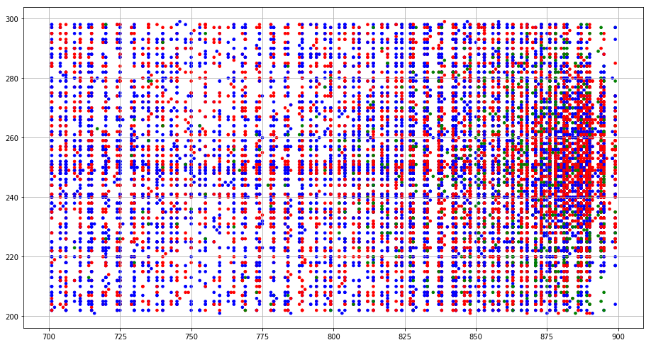

```python
# Shots on the paint

xr = rect1['location_x']
yr = rect1['location_y']
colors = np.where(rect1['current_shot_outcome']=='SCORED','r',np.where(rect1['current_shot_outcome']=='MISSED','b','g'))
plt.figure(figsize=(94/6,50/6))
plt.scatter(xr,yr, s=50, c= colors, marker= '.')
plt.grid(True)
```

But we can still zoom in further. Below we look at the area immediately under the basket:

```python
# subset area

rect2 = shot[(((shot['location_x']>850) & (shot['location_x']<875)) & \
                 ((shot['location_y'] > 240) & (shot['location_y'] < 260)))]
rect2
```

|  | self_previous_shot | player_position | home_game | location_x | opponent_previous_shot | home_team | shot_type | points | away_team | location_y | time | date | shoot_player | time_from_last_shot | quarter | current_shot_outcome | halfcourt_x | halfcourt_y |
| --- | --- | --- | --- | --- | --- | --- | --- | --- | --- | --- | --- | --- | --- | --- | --- | --- | --- | --- |
| 51 | MISSED | PF | Yes | 871.0 | SCORED | ATL | Driving Layup | 2 | WAS | 246.0 | 1:26 | 10/27/2016 | Paul Millsap | 24.0 | 3 | SCORED | 871.0 | 246.0 |
| 53 | MISSED | PF | Yes | 868.0 | SCORED | ATL | Driving Layup | 2 | WAS | 257.0 | 3:31 | 10/27/2016 | Paul Millsap | 58.0 | 3 | SCORED | 868.0 | 257.0 |
| 94 | MISSED | PG | No | 858.0 | MISSED | PHI | Driving Floating Jump Shot | 2 | ATL | 259.0 | 2:49 | 10/29/2016 | Dennis Schroder | 26.0 | 1 | SCORED | 858.0 | 259.0 |
| 120 | BLOCKED | C | No | 866.0 | MISSED | PHI | Layup | 2 | ATL | 254.0 | 4:14 | 10/29/2016 | Dwight Howard | 37.0 | 2 | BLOCKED | 866.0 | 254.0 |
| 299 | SCORED | C | Yes | 873.0 | MISSED | ATL | Driving Layup | 2 | LAL | 248.0 | 2:43 | 11/2/2016 | Dwight Howard | 30.0 | 3 | SCORED | 873.0 | 248.0 |
| 379 | MISSED | PG | No | 873.0 | SCORED | WAS | Running Finger Roll Layup | 2 | ATL | 251.0 | 10:15 | 11/4/2016 | Dennis Schroder | 41.0 | 2 | SCORED | 873.0 | 251.0 |
| 637 | MISSED | C | Yes | 866.0 | MISSED | ATL | Layup | 2 | CHI | 248.0 | 5:59 | 11/9/2016 | Dwight Howard | 30.0 | 3 | MISSED | 866.0 | 248.0 |
| 657 | MISSED | PG | Yes | 873.0 | SCORED | ATL | Driving Layup | 2 | CHI | 250.0 | 5:05 | 11/9/2016 | Dennis Schroder | 41.0 | 4 | MISSED | 873.0 | 250.0 |
| 770 | SCORED | C | No | 873.0 | MISSED | MIA | Layup | 2 | ATL | 257.0 | 5:15 | 11/15/2016 | Dwight Howard | 39.0 | 1 | MISSED | 873.0 | 257.0 |
| 775 | SCORED | C | No | 871.0 | SCORED | MIA | Alley Oop Layup | 2 | ATL | 244.0 | 8:07 | 11/15/2016 | Mike Muscala | 87.0 | 1 | MISSED | 871.0 | 244.0 |
| 787 | MISSED | SF | No | 868.0 | MISSED | MIA | Running Reverse Layup | 2 | ATL | 249.0 | 2:20 | 11/15/2016 | Kent Bazemore | 14.0 | 2 | SCORED | 868.0 | 249.0 |
| 928 | MISSED | C | No | 873.0 | SCORED | CHA | Layup | 2 | ATL | 241.0 | 5:38 | 11/18/2016 | Dwight Howard | 19.0 | 1 | SCORED | 873.0 | 241.0 |
| 1010 | MISSED | PG | No | 868.0 | SCORED | NYK | Driving Layup | 2 | ATL | 252.0 | 5:34 | 11/20/2016 | Dennis Schroder | 26.0 | 1 | BLOCKED | 868.0 | 252.0 |
| 1013 | MISSED | C | No | 868.0 | SCORED | NYK | Layup | 2 | ATL | 249.0 | 7:09 | 11/20/2016 | Mike Muscala | 48.0 | 1 | MISSED | 868.0 | 249.0 |
| 1169 | SCORED | PF | Yes | 868.0 | MISSED | ATL | Driving Layup | 2 | NOP | 249.0 | 11:28 | 11/22/2016 | Kris Humphries | 95.0 | 4 | SCORED | 868.0 | 249.0 |
| 1177 | SCORED | SF | No | 868.0 | SCORED | IND | Driving Finger Roll Layup | 2 | ATL | 259.0 | 3:28 | 11/23/2016 | Kent Bazemore | 29.0 | 1 | SCORED | 868.0 | 259.0 |
| 1182 | SCORED | C | No | 858.0 | SCORED | IND | Driving Layup | 2 | ATL | 259.0 | 6:39 | 11/23/2016 | Dwight Howard | 74.0 | 1 | SCORED | 858.0 | 259.0 |
| 1210 | MISSED | C | No | 874.0 | SCORED | IND | Layup | 2 | ATL | 245.0 | 7:57 | 11/23/2016 | Dwight Howard | 2.0 | 2 | BLOCKED | 874.0 | 245.0 |
| 1256 | MISSED | C | No | 853.0 | NaN | UTA | Hook Shot | 2 | ATL | 241.0 | 0:36 | 11/25/2016 | Dwight Howard | 13.0 | 1 | BLOCKED | 853.0 | 241.0 |
| 1270 | MISSED | C | No | 866.0 | MISSED | UTA | Driving Layup | 2 | ATL | 241.0 | 8:06 | 11/25/2016 | Dwight Howard | 29.0 | 1 | BLOCKED | 866.0 | 241.0 |
| 1289 | MISSED | SF | No | 863.0 | MISSED | UTA | Running Layup | 2 | ATL | 250.0 | 7:37 | 11/25/2016 | Kent Bazemore | 22.0 | 2 | MISSED | 863.0 | 250.0 |
| 1341 | SCORED | C | No | 868.0 | MISSED | LAL | Layup | 2 | ATL | 252.0 | 1:56 | 11/27/2016 | Dwight Howard | 33.0 | 1 | SCORED | 868.0 | 252.0 |
| 1430 | MISSED | SF | No | 873.0 | SCORED | GSW | Running Layup | 2 | ATL | 251.0 | 2:37 | 11/28/2016 | Kent Bazemore | 33.0 | 1 | MISSED | 873.0 | 251.0 |
| 1461 | SCORED | PG | No | 863.0 | MISSED | GSW | Driving Layup | 2 | ATL | 241.0 | 8:43 | 11/28/2016 | Dennis Schroder | 27.0 | 2 | BLOCKED | 863.0 | 241.0 |
| 1536 | SCORED | C | No | 858.0 | MISSED | PHX | Jump Shot | 2 | ATL | 252.0 | 1:45 | 11/30/2016 | Mike Muscala | 40.0 | 2 | MISSED | 858.0 | 252.0 |
| 1672 | MISSED | SG | Yes | 873.0 | BLOCKED | ATL | Jr. 2' Driving Layup | 2 | DET | 248.0 | 2:22 | 12/2/2016 | Tim Hardaway Jr. | 6.0 | 4 | SCORED | 873.0 | 248.0 |
| 1724 | MISSED | C | No | 873.0 | MISSED | TOR | Putback Layup | 2 | ATL | 248.0 | 5:38 | 12/3/2016 | Mike Muscala | 4.0 | 2 | SCORED | 873.0 | 248.0 |
| 1728 | SCORED | PG | No | 853.0 | SCORED | TOR | Driving Floating Jump Shot | 2 | ATL | 248.0 | 8:26 | 12/3/2016 | Dennis Schroder | 30.0 | 2 | SCORED | 853.0 | 248.0 |
| 1730 | MISSED | C | No | 863.0 | MISSED | TOR | Tip Layup Shot | 2 | ATL | 246.0 | 9:11 | 12/3/2016 | Dwight Howard | 2.0 | 2 | MISSED | 863.0 | 246.0 |
| 1733 | MISSED | SG | No | 871.0 | SCORED | TOR | 24' 3PT Jump Shot | 3 | ATL | 246.0 | 11:23 | 12/3/2016 | Tim Hardaway Jr. | 31.0 | 2 | MISSED | 871.0 | 246.0 |
| ... | ... | ... | ... | ... | ... | ... | ... | ... | ... | ... | ... | ... | ... | ... | ... | ... | ... | ... |
| 208833 | SCORED | PG | Yes | 858.0 | SCORED | WAS | Jump Shot | 2 | CHI | 251.0 | 11:10 | 3/17/2017 | John Wall | 42.0 | 3 | BLOCKED | 858.0 | 251.0 |
| 209164 | MISSED | C | Yes | 873.0 | SCORED | WAS | Layup | 2 | BRO | 251.0 | 0:13 | 3/24/2017 | Marcin Gortat | NaN | 3 | MISSED | 873.0 | 251.0 |
| 209240 | MISSED | SG | No | 868.0 | MISSED | CLE | Driving Layup | 2 | WAS | 256.0 | 2:06 | 3/25/2017 | Bradley Beal | 21.0 | 2 | BLOCKED | 868.0 | 256.0 |
| 209304 | SCORED | PG | No | 873.0 | MISSED | LAL | Layup | 2 | WAS | 258.0 | 3:44 | 3/28/2017 | John Wall | 11.0 | 1 | BLOCKED | 873.0 | 258.0 |
| 209312 | SCORED | PF | No | 873.0 | SCORED | LAL | Morris 2' Cutting Layup Shot | 2 | WAS | 257.0 | 6:56 | 3/28/2017 | Markieff Morris | 30.0 | 1 | SCORED | 873.0 | 257.0 |
| 209315 | SCORED | C | No | 853.0 | SCORED | LAL | Jump Shot | 2 | WAS | 258.0 | 8:29 | 3/28/2017 | Marcin Gortat | 42.0 | 1 | BLOCKED | 853.0 | 258.0 |
| 209318 | MISSED | SF | No | 868.0 | SCORED | LAL | Jr. 2' Layup | 2 | WAS | 257.0 | 10:19 | 3/28/2017 | Kelly Oubre Jr. | 3.0 | 1 | BLOCKED | 868.0 | 257.0 |
| 209332 | SCORED | C | No | 871.0 | SCORED | LAL | Layup | 2 | WAS | 257.0 | 5:01 | 3/28/2017 | Ian Mahinmi | 28.0 | 2 | SCORED | 871.0 | 257.0 |
| 209339 | MISSED | SG | No | 873.0 | SCORED | LAL | Jump Bank Shot | 2 | WAS | 250.0 | 8:16 | 3/28/2017 | Bradley Beal | 9.0 | 2 | MISSED | 873.0 | 250.0 |
| 209340 | MISSED | PF | No | 872.0 | SCORED | LAL | Morris 2' Alley Oop Layup | 2 | WAS | 251.0 | 8:34 | 3/28/2017 | Markieff Morris | 18.0 | 2 | SCORED | 872.0 | 251.0 |
| 209345 | SCORED | PG | No | 871.0 | MISSED | LAL | Reverse Layup | 2 | WAS | 255.0 | 11:57 | 3/28/2017 | John Wall | 33.0 | 2 | MISSED | 871.0 | 255.0 |
| 209404 | SCORED | PG | No | 858.0 | MISSED | LAC | Jump Shot | 2 | WAS | 248.0 | 6:28 | 3/29/2017 | John Wall | 27.0 | 1 | MISSED | 858.0 | 248.0 |
| 209405 | MISSED | C | No | 873.0 | MISSED | LAC | Putback Layup | 2 | WAS | 246.0 | 6:33 | 3/29/2017 | Marcin Gortat | 5.0 | 1 | SCORED | 873.0 | 246.0 |
| 209406 | SCORED | PG | No | 861.0 | MISSED | LAC | Running Layup | 2 | WAS | 244.0 | 6:50 | 3/29/2017 | John Wall | 17.0 | 1 | SCORED | 861.0 | 244.0 |
| 209409 | SCORED | PG | No | 866.0 | SCORED | LAC | Layup | 2 | WAS | 256.0 | 8:22 | 3/29/2017 | John Wall | 29.0 | 1 | BLOCKED | 866.0 | 256.0 |
| 209410 | BLOCKED | C | No | 868.0 | SCORED | LAC | Layup | 2 | WAS | 244.0 | 8:33 | 3/29/2017 | Jason Smith | 11.0 | 1 | MISSED | 868.0 | 244.0 |
| 209415 | MISSED | C | No | 858.0 | SCORED | LAC | Hook Shot | 2 | WAS | 252.0 | 11:17 | 3/29/2017 | Ian Mahinmi | 2.0 | 1 | MISSED | 858.0 | 252.0 |
| 209512 | MISSED | SF | No | 873.0 | BLOCKED | UTA | Layup | 2 | WAS | 251.0 | 2:17 | 3/31/2017 | Bojan Bogdanovic | 26.0 | 2 | BLOCKED | 873.0 | 251.0 |
| 209518 | MISSED | C | No | 853.0 | SCORED | UTA | Hook Shot | 2 | WAS | 249.0 | 5:44 | 3/31/2017 | Ian Mahinmi | 64.0 | 2 | MISSED | 853.0 | 249.0 |
| 209524 | MISSED | PG | No | 873.0 | MISSED | UTA | Driving Layup | 2 | WAS | 254.0 | 8:26 | 3/31/2017 | John Wall | 48.0 | 2 | SCORED | 873.0 | 254.0 |
| 209571 | NaN | SG | No | 871.0 | NaN | GSW | Driving Layup | 2 | WAS | 256.0 | 0:23 | 4/2/2017 | Bradley Beal | NaN | 1 | MISSED | 871.0 | 256.0 |
| 209578 | SCORED | SG | No | 861.0 | SCORED | GSW | Driving Layup | 2 | WAS | 241.0 | 3:47 | 4/2/2017 | Bradley Beal | 40.0 | 1 | SCORED | 861.0 | 241.0 |
| 209580 | SCORED | C | No | 871.0 | MISSED | GSW | Cutting Layup Shot | 2 | WAS | 252.0 | 4:43 | 4/2/2017 | Marcin Gortat | 37.0 | 1 | SCORED | 871.0 | 252.0 |
| 209597 | MISSED | SF | No | 861.0 | SCORED | GSW | Jr. 3' Layup | 2 | WAS | 249.0 | 0:37 | 4/2/2017 | Kelly Oubre Jr. | 2.0 | 2 | BLOCKED | 861.0 | 249.0 |
| 209605 | SCORED | PG | No | 871.0 | MISSED | GSW | Layup | 2 | WAS | 249.0 | 8:05 | 4/2/2017 | John Wall | 23.0 | 2 | BLOCKED | 871.0 | 249.0 |
| 209719 | MISSED | PF | Yes | 868.0 | SCORED | WAS | Morris 2' Driving Reverse Layup | 2 | CHA | 248.0 | 6:27 | 4/4/2017 | Markieff Morris | 32.0 | 3 | SCORED | 868.0 | 248.0 |
| 209749 | MISSED | C | No | 851.0 | SCORED | NYK | Jump Shot | 2 | WAS | 254.0 | 1:50 | 4/6/2017 | Marcin Gortat | 58.0 | 1 | SCORED | 851.0 | 254.0 |
| 209863 | MISSED | C | Yes | 873.0 | SCORED | WAS | Tip Layup Shot | 2 | MIA | 259.0 | 1:46 | 4/8/2017 | Marcin Gortat | 3.0 | 3 | SCORED | 873.0 | 259.0 |
| 209887 | SCORED | SF | Yes | 868.0 | SCORED | WAS | Layup | 2 | MIA | 251.0 | 4:02 | 4/8/2017 | Bojan Bogdanovic | 62.0 | 4 | BLOCKED | 868.0 | 251.0 |
| 209999 | SCORED | PG | No | 873.0 | MISSED | MIA | Finger Roll Layup | 2 | WAS | 248.0 | 6:22 | 4/12/2017 | Brandon Jennings | 33.0 | 1 | MISSED | 873.0 | 248.0 |

3533 rows × 18 columns

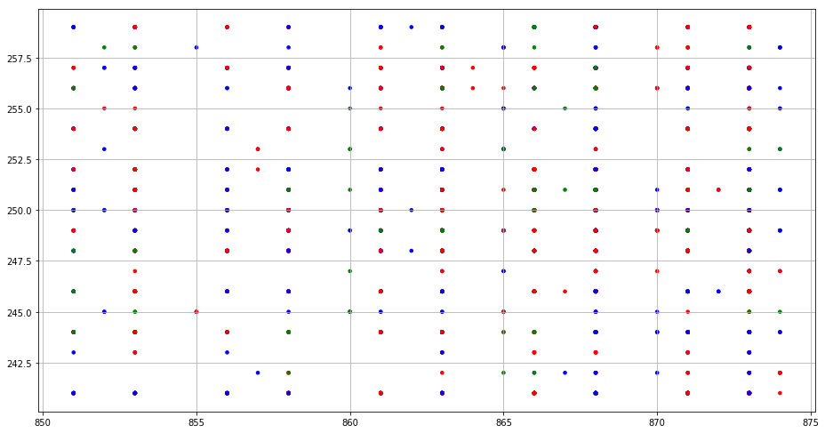

```python
# Shots under the basket

xq = rect2['location_x']
yq = rect2['location_y']
colors = np.where(rect2['current_shot_outcome']=='SCORED','r',np.where(rect2['current_shot_outcome']=='MISSED','b','g'))
plt.figure(figsize=(94/6,50/6))
plt.scatter(xq,yq, s=50, c= colors, marker= '.')
plt.grid(True)
```

# Conclusion

Using charts can be incredibly helpful in understanding the pattern of events on the field/court/pitch/ice. Charts can suggest to us logical relationships which may exist, but they do not quantify them. In the next two weeks we turn to regression analysis, which is one of the most common ways to quantify relationships among variables.